# slides slides

```python
%%html
<style type="text/css">

.reveal table {
    font-size: 1em;
}

.reveal div.jp-MarkdownOutput {
    font-size: 30px;
}

.reveal div.highlight>pre {
    margin: 0;
    width: 100%;
    font-size: 25px;
}

.reveal div.jp-OutputArea-output>pre {
    margin: 0;
    width: 90%;
    font-size: 25px;
    box-shadow: none;
}

.center {
  margin: auto;
  padding: 10px;
  text-align: center;
}

</style>
```

### Krešimir Kumerički, University of Zagreb

(@ IMP, Lanzhou, 28 June 2023)

[figure not shown]

### It is **Gepard**, and not **GeParD**!

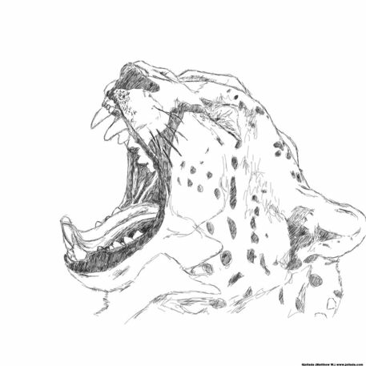

### **Gepard** - software tool for studying GPDs

- Modelling Generalized Parton Distributions (GPDs) and Compton form factors (CFFs).
- Perturbative NLO QCD evolution of GPDs
- Calculation of deeply virtual Compton scattering (DVCS) and deeply virtual (vector) meson production (DVMP) observables to NLO accuracy.
- Fitting parametrized models to the experimental data.

| **Old Gepard** | **New Gepard** |
| --- | --- |
| Fortran + C + Python | Python |
| NNLO, Neural nets | NLO only |
| 2x faster |  |
| also public now |  |

Sources are on `github.com`, but you can just install Gepard as any "official" Python package

```
% pip install gepard
```

For interactive work, it is best to use Jupyter notebooks.

```python
import gepard as g
print(g.__version__)
```

```
0.9.10
```

## Simple use

(Just want to calculate observables / CFFs / GPDs for available models.)

`DataPoint` **object**: contains information about kinematics and, possibly, about particular measurement perfomed at that kinematics

`Theory` **object**: contains algorithms for evaluation of various structure functions (CFFs, GPDs, …) and observables (cross-sections, asymmetries, …) for a given data point

```python
# Constructing DataPoint object:
pt = g.DataPoint(xB=0.348, t=-0.3, Q2=3., phi=0.3)
```

```python
# Some Theory objects are available already:
from gepard.fits import th_KM15
th_KM15.XGAMMA(pt)   # gamma* cross-section
```

```
16.338827100957786
```

```python
th_KM15.ImH(pt)  # calculating CFF
```

```
2.8075442714080117
```

```python
# Experimental measurement datapoint:
pt = g.DataPoint(xB=0.348, t=-0.3, Q2=3., phi=0.3,
                 process='ep2epgamma', in1charge=-1,
                 exptype='fixed target', in1energy=6.,
                 in1polarization=+1,
                 observable='XS', val=0.21, err=0.01)

pt.W, pt.xi   # auto-calculated kinematics
```

```
(2.5497144988314844, 0.21065375302663436)
```

```python
# There is a database of datasets available:
g.describe_data(g.dset[32])
```

```
npt x obs     collab  FTn    id  ref.
----------------------------------------------
18 x AC      HERMES  0.0    32  arXiv:0909.3587
18 x AC      HERMES  1.0    32  arXiv:0909.3587
----------------------------------------------
TOTAL = 36
```

```python
th_KM15.chisq(g.dset[32])  # chi-square for dataset
```

```
20.525561762363598
```

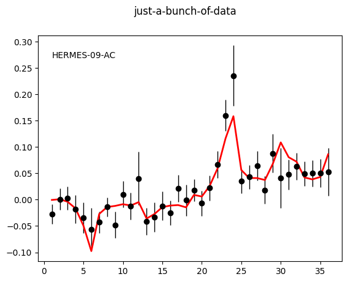

```python
from gepard.plots import jbod  # just a bunch of data
fig = jbod(points=g.dset[32], lines=th_KM15)
```

## Advanced use

(Constructing new models and fitting them to data.)

```python
class MyTheory(g.PWNormGPD, g.MellinBarnesCFF, g.DIS,
               g.BMK):
    pass

th = MyTheory(p=1)  # instance of Theory object
```

- for GPDs we take SO(3) partial-waves conformal space model `PWNormGPD`,
- for CFFs we take `MellinBarnesCFF` which combines conformal space GPDs with appropriate hard-scattering coefficients,

```python
pts = g.dset[39]+g.dset[206]
g.describe_data(pts)
```

```
npt x obs     collab  FTn    id  ref.
----------------------------------------------
10 x DISF2   H1      N/A    206 Nucl.Phys.B470(96)3
 8 x XGAMMA  H1      N/A    39  hep-ex/0505061
----------------------------------------------
TOTAL = 18
```

```python
th.chisq(pts)  # very bad chi-square
```

```
351.1879172212425
```

```python
# Construction of Fitter object
# ... relying on iminuit package
f = g.MinuitFitter(pts, th)
# Adjusting sea-quarks normalization and t-dependence
f.release_parameters('ns', 'ms2', 'secs')
f.fit()
```

```python
th.chisq(pts) / len(pts)  # chi-square
```

```
0.35169097347926753
```

```python
f.minuit.covariance  # access iminuit functionalities
```

[output not shown]

## Some features

```python
# conversion to pandas DataFrame
pts.df()[['xB', 't', 'val']].head()
```

|  | xB | t | val |
| --- | --- | --- | --- |
| 0 | 0.000793 | -0.1 | 29.90 |
| 1 | 0.000793 | -0.3 | 8.00 |
| 2 | 0.000793 | -0.5 | 2.13 |
| 3 | 0.000793 | -0.8 | 0.27 |
| 4 | 0.001189 | -0.1 | 13.30 |

```python
# kinematical cuts
cut_pts = g.select(g.dset[39], criteria=['Q2 > 5'])
cut_pts.df().Q2.min()  # minimal Q2 in set after cut
```

```
8.0
```

```python
# x-space GPDs  (only for x=0, x=xi)
ptx = g.DataPoint(x=0.01, eta=0.01, t=-0.2, Q2=8)
th.Hx(ptx)
```

```
array([ 31.29251363, 383.115633  ,   0.        ])
```

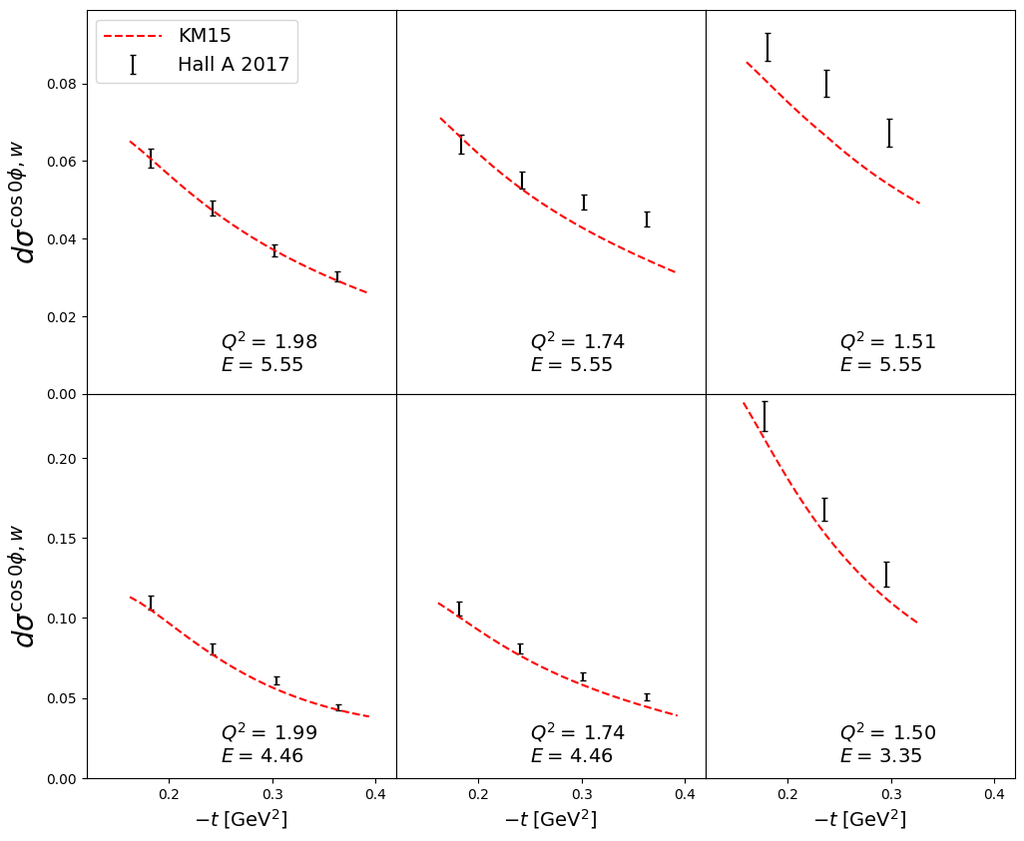

```python
# Predefined plots for some experimental sets
from gepard.plots import HallA17
fig = HallA17(lines=th_KM15)
```

```python
# Most of the functions are thoroughly documented:
print(g.DataPoint.__doc__)
```

```
Kinematical point. May correspond to actual measurement.

    Args:
        xB (float): Bjorken x_B
        t (float): momentum transfer to target squared
        Q2 (float): Q^2
        phi (float): azimuthal angle
        FTn (int): harmonic of azimuthal angle, e.g. -1 for sin(phi)
        observable (str): name of the measured observable
        val (float): measurement value
        err (float): total uncertainty of `val`
        units (dict): pysical units of variables
        kindict (dict): for old, alternative passing of kinematics values,
                 like ``g.DataPoint({'xB': 0.1, 't': -0.2, 'Q2': 4.0})``

    There are other args as well.

    Examples:
            >>> pt = g.DataPoint(xB=0.1, t=-0.2, Q2=4.0)

    Todo:
        `kindict` is temporarily kept for backward compatibility.
        You should not rely on it.
```

## Cross-checks

Large suite of tests (where most of test values are produced by independent implementations by D. Mueller, K. Passek-Kumerički and M. Čuić.)

```python
!pytest C:\Users\kkumer\gepard\tests
```

```
============================= test session starts =============================
platform win32 -- Python 3.11.3, pytest-7.3.1, pluggy-1.0.0
rootdir: C:\Users\kkumer\gepard
configfile: pytest.ini
plugins: anyio-3.7.0
collected 111 items

..\gepard\tests\GK_test.py ..........                                    [  9%]
..\gepard\tests\adacf_test.py .                                          [  9%]
..\gepard\tests\cff_test.py ...........s..s.......                       [ 29%]
..\gepard\tests\dvmp_test.py ....s                                       [ 34%]
..\gepard\tests\elastic_ff_test.py .......                               [ 40%]
..\gepard\tests\evol_test.py .....                                       [ 45%]
..\gepard\tests\fit_test.py ss.ss                                        [ 49%]
..\gepard\tests\fits_KM_test.py ..ssss.s                                 [ 56%]
..\gepard\tests\gpd_test.py ........                                     [ 63%]
..\gepard\tests\observables_test.py ....ss...............                [ 82%]
..\gepard\tests\special_test.py .......                                  [ 89%]
..\gepard\tests\theory_test.py ...........s                              [100%]

============================== warnings summary ===============================
..\gepard\src\gepard\quadrature.py:9
  C:\Users\kkumer\gepard\src\gepard\quadrature.py:9: DeprecationWarning: Please use `p_roots` from the `scipy.special` namespace, the `scipy.special.orthogonal` namespace is deprecated.
    from scipy.special.orthogonal import p_roots

-- Docs: https://docs.pytest.org/en/stable/how-to/capture-warnings.html
================== 96 passed, 15 skipped, 1 warning in 8.41s ==================
```

Checking evolution code:

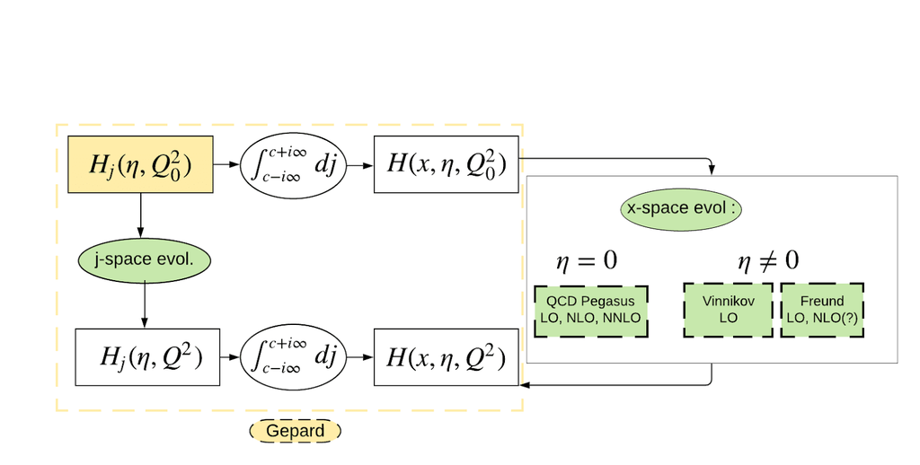

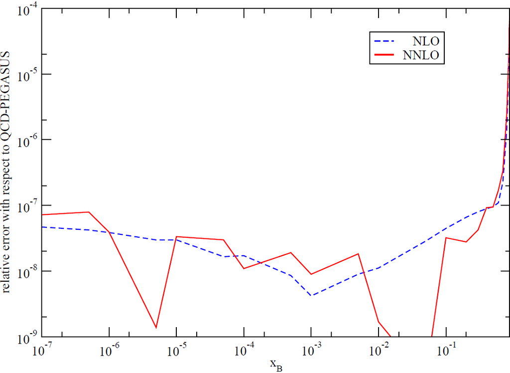

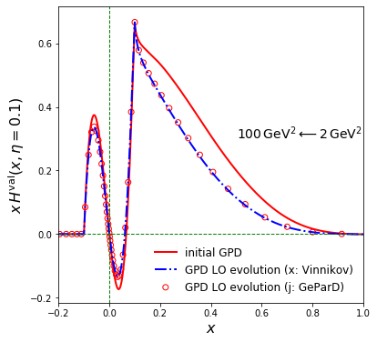

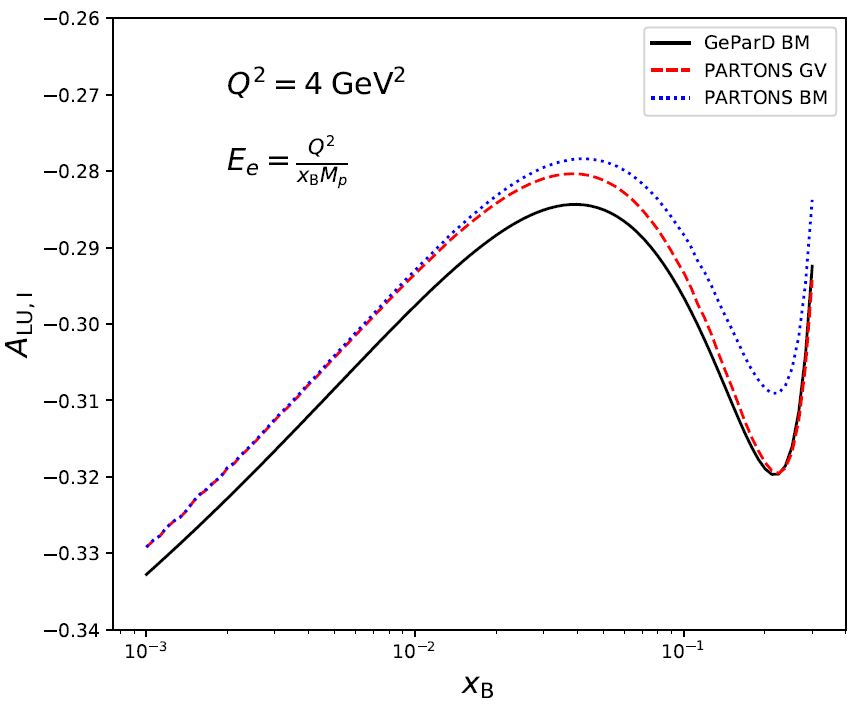

## For more, go to https://gepard.phy.hr

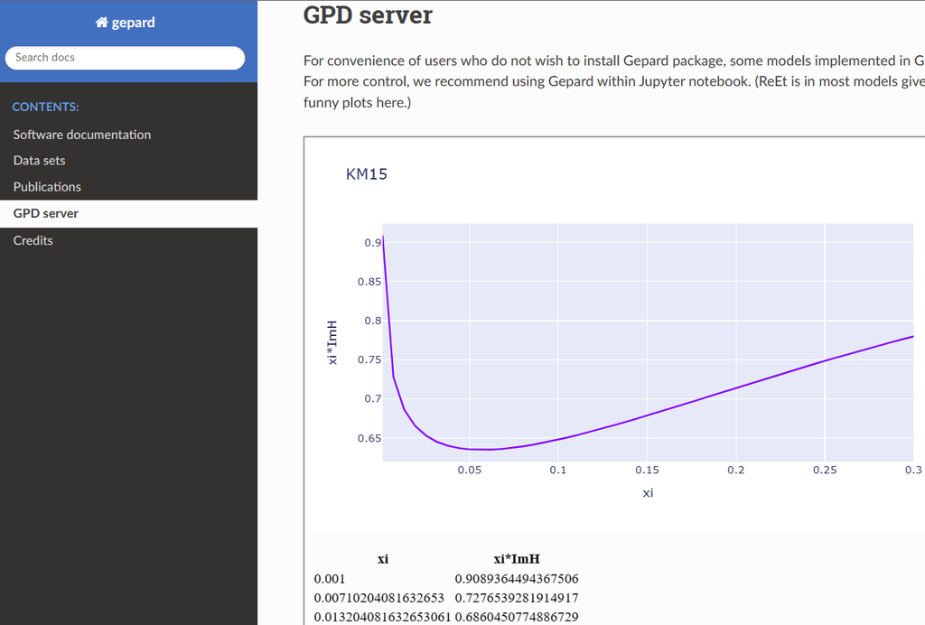

# Part II: Gepard + PyTorch tutorial

The following runs when using `torch` Gepard branch from Github. It is **not** at the moment **compatible** with `master` branch.

So, after `git checkout torch` and after restarting the Jupyter kernel:

```python
import gepard as g
import gepard.plots as gplots  # some prepared plots
from gepard.fits import GLO15new, AUTIpts, ALUIpts   # Selection of old JLab and HERMES datasets
import torch
import matplotlib.pyplot as plt
```

```python
fitpoints = g.dset[31] + g.dset[8]
g.describe_data(fitpoints)
```

```
npt x obs     collab  FTn    id  ref.
----------------------------------------------
12 x AC      HERMES  0.0    31  arXiv:0802.2499
12 x AC      HERMES  1.0    31  arXiv:0802.2499
12 x ALU     CLAS    -1.0   8   arXiv:0711.4805
----------------------------------------------
TOTAL = 36
```

```python
class NNTest(g.model.NeuralModel, g.eff.DipoleEFF, g.dvcs.BMK):

    def build_net(self):
        '''Overriding the default architecture and optimizer'''
        nn_model = torch.nn.Sequential(
                torch.nn.Linear(2, 12),
                torch.nn.ReLU(),
                torch.nn.Linear(12, 17),
                torch.nn.ReLU(),
                torch.nn.Linear(17, 12),
                torch.nn.ReLU(),
                torch.nn.Linear(12, len(self.output_layer))
            )
        optimizer = torch.optim.Rprop(nn_model.parameters(),
                lr=0.05)
        return nn_model, optimizer
```

We now create theory object instance, and can specify CFFs that will be represented by the neural net:

```python
th = NNTest(output_layer=['ImH', 'ReH'])
```

Now we create instance of the `NeuralFitter` object, where in addition to obligatory arguments (list of datapoints and theory object), we can control details of the fitting process:

```python
f = g.fitter.NeuralFitter(fitpoints, th, nnets=3, maxtries=100, nbatch=6, batchlen=10)
```

[output not shown]

```python
%%time
f.fitgood()
```

```
Epoch 10: train error = 1.24 test error = 2.65
Epoch 20: train error = 1.10 test error = 4.66
Epoch 30: train error = 1.02 test error = 3.47
Epoch 40: train error = 0.87 test error = 1.67
Epoch 50: train error = 0.86 test error = 1.82
Epoch 60: train error = 0.84 test error = 1.71
[Try 1/100] 1 good nets. Last test_err = 1.665133191153046
Epoch 10: train error = 3.30 test error = 2.84
Epoch 20: train error = 2.16 test error = 1.04
Epoch 30: train error = 1.78 test error = 0.98
Epoch 40: train error = 1.66 test error = 1.09
Epoch 50: train error = 1.42 test error = 1.08
Epoch 60: train error = 1.17 test error = 1.29
[Try 2/100] 2 good nets. Last test_err = 0.9825117464444691
Epoch 10: train error = 1.90 test error = 4.93
Epoch 20: train error = 1.63 test error = 5.03
Epoch 30: train error = 1.50 test error = 4.86
Epoch 40: train error = 1.43 test error = 4.19
Epoch 50: train error = 1.41 test error = 4.24
Epoch 60: train error = 1.35 test error = 3.38
[Try 3/100] 2 good nets. Last test_err = 3.380725017752141
Epoch 10: train error = 3.77 test error = 1.10
Epoch 20: train error = 2.66 test error = 0.93
Epoch 30: train error = 2.51 test error = 0.98
Epoch 40: train error = 1.85 test error = 1.05
Epoch 50: train error = 1.25 test error = 1.61
Epoch 60: train error = 0.86 test error = 1.46
[Try 4/100] 3 good nets. Last test_err = 0.9256169140876209
CPU times: total: 1min 10s
Wall time: 1min 11s
```

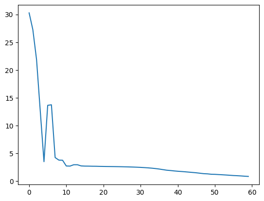

```python
plt.plot(f.history)
plt.show()
```

Now theory has three trained nets, and future predictions are calculated by evaluating all nets and taking the mean value of results:

```python
th.predict(fitpoints[0], uncertainty=True)  # mean value and standard deviation
```

```
(-0.004126455065628961, 0.0021177377825266205)
```

You can also get individual predictions by all nets:

```python
th.predict(fitpoints[0], mesh=True)
```

```
array([-0.00603334, -0.00517303, -0.001173  ])
```

Plotting the mean value and error band for total dataset:

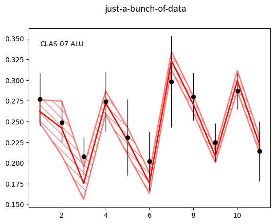

```python
fig = gplots.jbod(points=fitpoints[-11:], lines=[th], bands=[th])
```

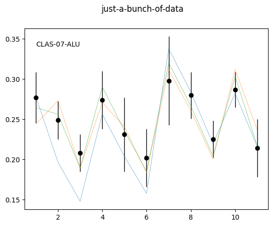

```python
fig = gplots.jbod(points=fitpoints[-11:], mesh=th)   # Plot the mesh of individual nets
```

# Impact of EicC simulated data

```python
class NNTest10(g.model.NeuralModel, g.eff.DipoleEFF, g.dvcs.BM10tw2):
    pass

thold = NNTest10(output_layer=['ReH', 'ImH', 'ReE', 'ImE', 'ImHt', 'ReHt'])
thnew = NNTest10(output_layer=['ReH', 'ImH', 'ReE', 'ImE', 'ImHt', 'ReHt'])
```

```python
thold.name = 'JLab+HERMES'
thnew.name = 'JLab+HERMES+EicC'
```

```python
# only 8 nets are saved from 10, I removed two worst nets by hand
thold.nets = torch.load('old.tar')
thnew.nets = torch.load('new.tar')
```

Check how these two models describe EicC data:

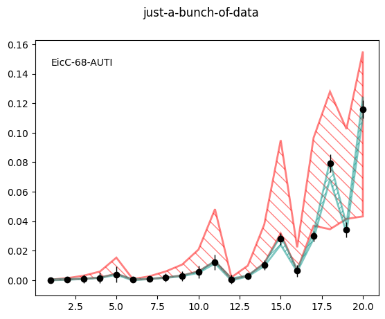

```python
fig = gplots.jbod(points=g.dset[3004][:20], bands=[thold, thnew])
```

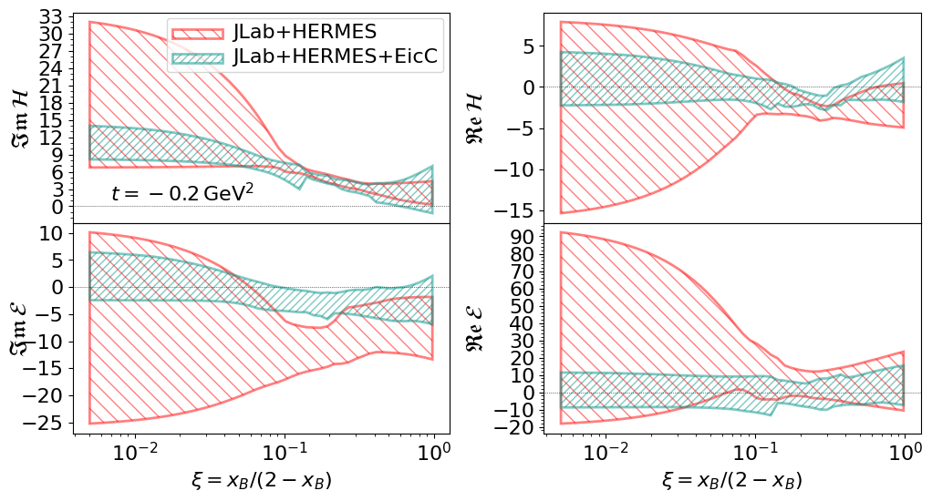

```python
fig = gplots.CFF3log(cffs=['ImH', 'ReH', 'ImE', 'ReE'],  bands=[thold, thnew], tval=-0.2)
```

This figure is roughly similar to the one in EicC white paper arXiv:2102.09222, Fig. 2.12. It is not exacly the same because for Fig 2.12 more nets have been trained and more care was exercised in prunig the nets with anomalous behaviour or too large chi-square. Also, procedure is inherently statistical so you will never get exactly the same plot.

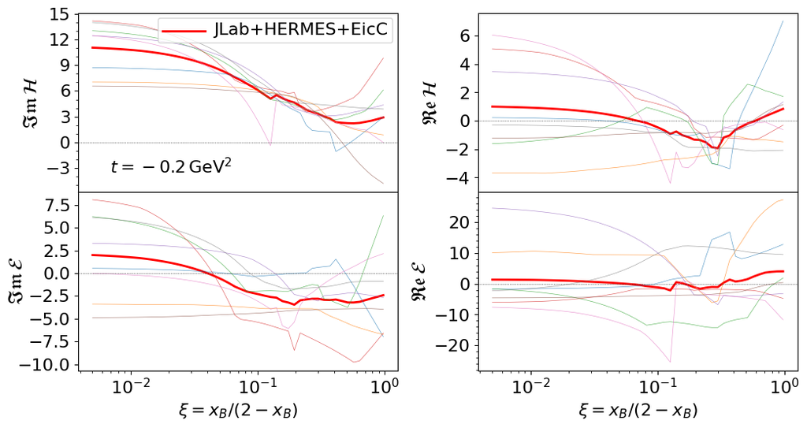

```python
fig = gplots.CFF3log(cffs=['ImH', 'ReH', 'ImE', 'ReE'], lines=[thnew], mesh=thnew, tval=-0.2)
```

Also, one should probably use some model regularization while training the model. In the meantime L1 and L2 regularizations are implemented in Gepard.